# Supplementary Material

## Fitting Part 1

To estimate participants accuracy over distance, we used a general linear model with using a binomial family. The “psyphy” package was used so as to inform the model that there were only two choices available to the participant, and as such, chance level was 50%.

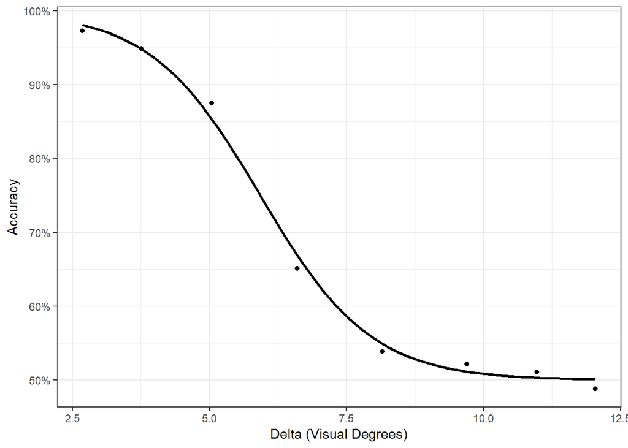

```r
load("../Analysis/scratch/Part1_peng")

# get aggregated data
agDat <- df %>%
  na.omit() %>%
  group_by(participant, separation) %>%
  summarise(Accuracy = mean(accuracy))

# pick example participant
participant <- "19"

# plot data
plt_curve <- agDat[agDat$participant == participant,] %>%
  ggplot(aes(get_VisDegs(separation/ppcm, Screen_dist), Accuracy)) +
  geom_smooth(colour = "black", method = glm,
              method.args = list(family = binomial(mafc.logit(2))),
              se = F, fullrange = T) +
  scale_y_continuous(labels = scales::percent_format(accuracy = 1)) +
  geom_point() +
  theme_bw()
plt_curve$labels$y <- "Accuracy"
plt_curve$labels$x <- "Delta (Visual Degrees)"
plt_curve
```

## Getting values for the priors

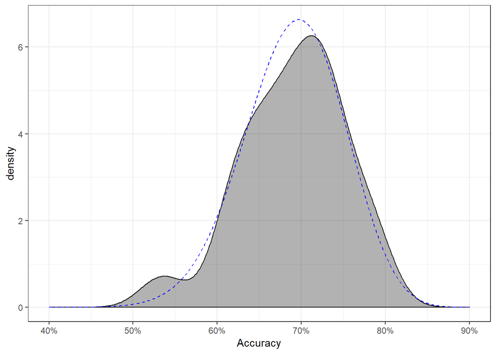

```r
# load data
load("../Analysis/scratch/Part1")
# make plot
plt_part1 <- m_dat %>%
  ggplot(aes(accuracy)) +
  geom_density(fill = "black",
               alpha = 0.3) +
  scale_x_continuous(labels = scales::percent_format(accuracy = 1),
                     limits = c(0.4, 0.9)) +
  theme_bw()
plt_part1$labels$x <- "Accuracy"

# get values for priors
prior_est <- fitdistrplus::fitdist(m_dat$accuracy, "beta")
a <- as.numeric(prior_est$estimate[1])
b <- as.numeric(prior_est$estimate[2])

prior_shape <- data.frame(x = seq(0,1.001,0.001),
                          y = dbeta(seq(0,1.001,0.001),a, b))

plt_part1 +
  geom_line(data = prior_shape,
            aes(x, y),
            colour = "blue",
            linetype = 2)
```

## Models of accuracy including distance

In these models, group membership, delta, and the interaction between these were added as parameters. With increasing distance between the boxes (delta), there should be a drop in performance. Delta was scaled by dividing the value (in pixels) by the maximum value at which each participant was tested. This was carried out for both Actual and Expected accuracy (see the main text for details).

Actual accuracy: As can be seen in the left plot below, participants in the control group had the lowest rate of success across all distances. For all groups, increased distance of the boxes did result in a lower accuracy rate. The effect of delta was larger for the Optimal and Motivated groups when compared to the Control group, and this is likely due to the lower intercept for the Control group.

Expected accuracy: We also modelled expected accuracy based on fixation choice and session 1 accuracy, as described in the main text. This isolates the effect of fixation choice from changes in accuracy due to other sources (such as attentiveness and luck). This is shown in the right plot below – it is clear there is now no effect of motivation when compared to the control group. This fits with the original conclusion that participants in the Motivated group were not making more optimal fixation decisions and instead must have been trying harder in other ways in order to achieve the greater rate of success compared to the control group that is observed in the actual accuracy rates.

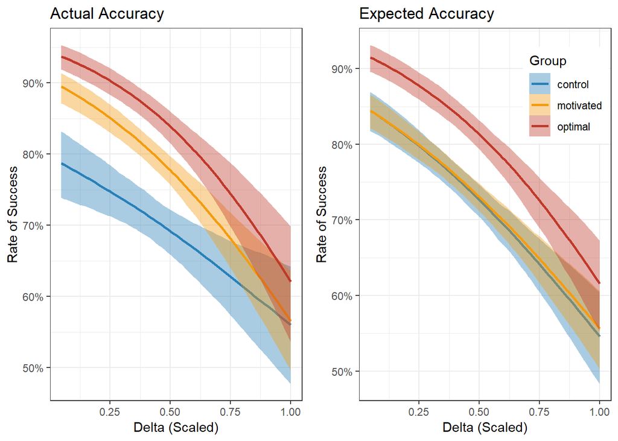